# CFTC Speculative Positions

アセット･マネジメント･コンサルティング株式会社 http://am-consulting.co.jp

2017-07-10 04:22:31

- アセット･マネジメント･コンサルティング株式会社 http://am-consulting.co.jp
- SaECaNet http://saecanet.com/
- Olive http://olive.saecanet.com/
- twitter https://twitter.com/AMC2_Japan
- 本ページへのリンクを共有:[Tweet](https://twitter.com/share)
- タイトル : CFTC投機筋ポジション-2017年07月03日分.Net 日本円:-75036, ユーロ:77464, 英ポンド:-27767, 豪ドル:32414, スイスフラン:-113, Gold:93799
- データ出所 : Commodity Futures Trading Commission , Federal Reserve Bank of St. Louis
- Source http://www.cftc.gov/index.htm

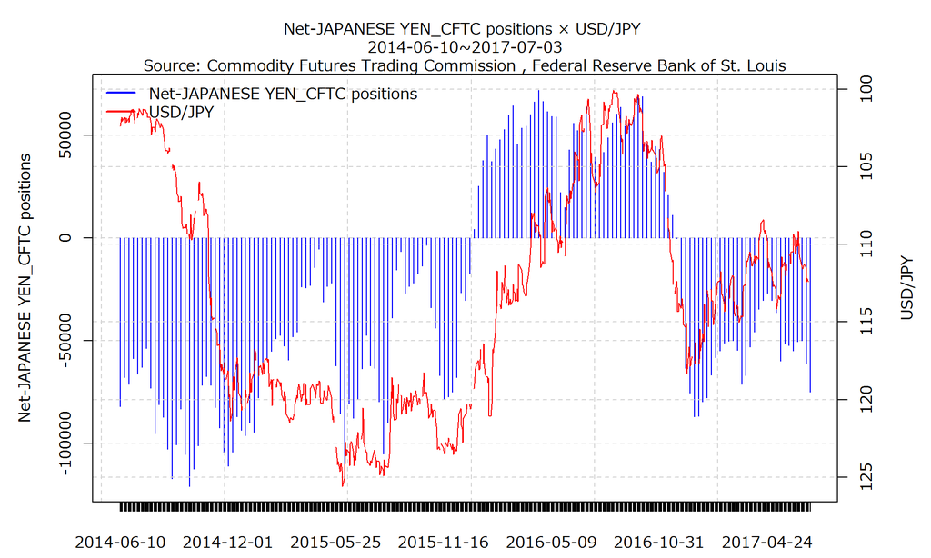

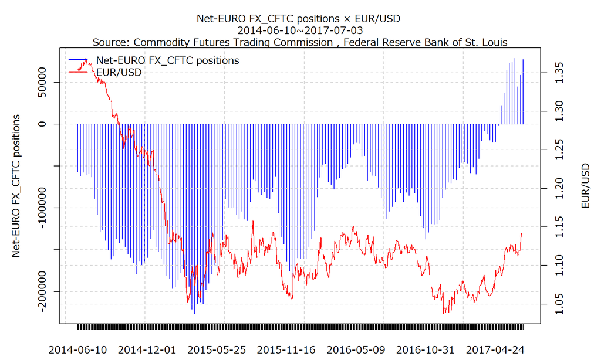

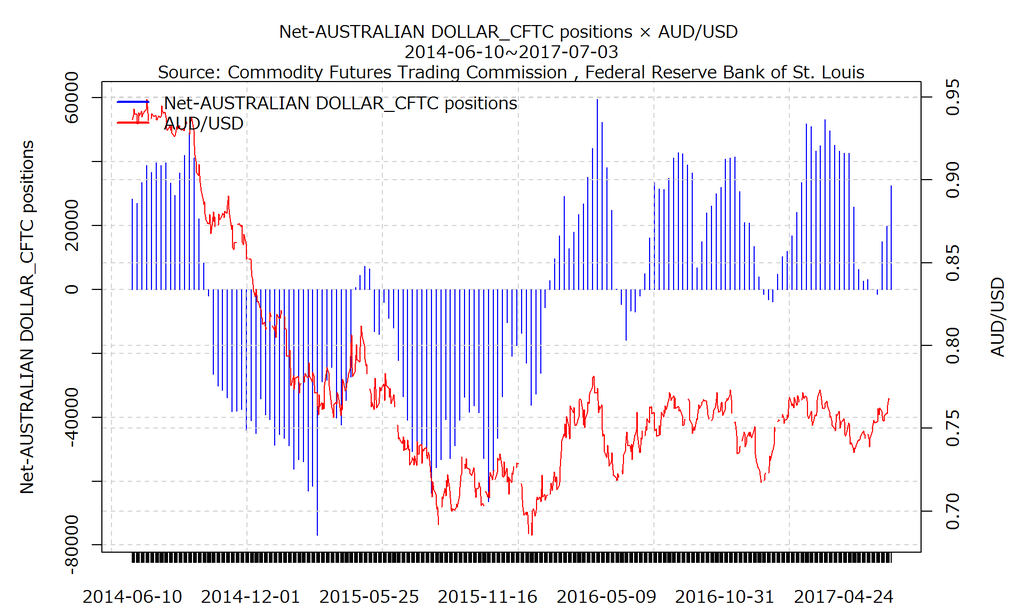

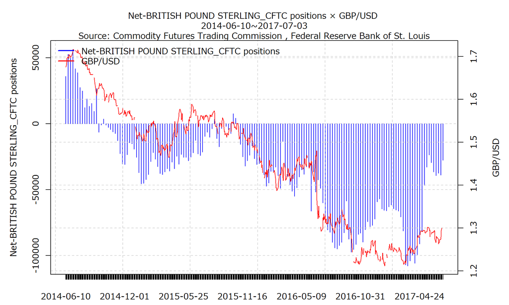

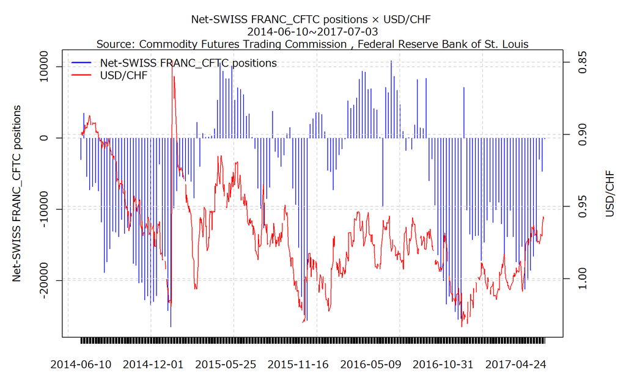

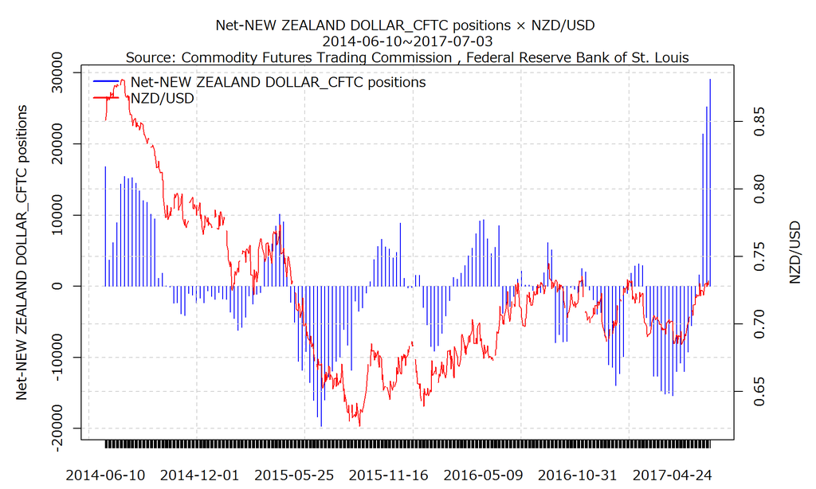

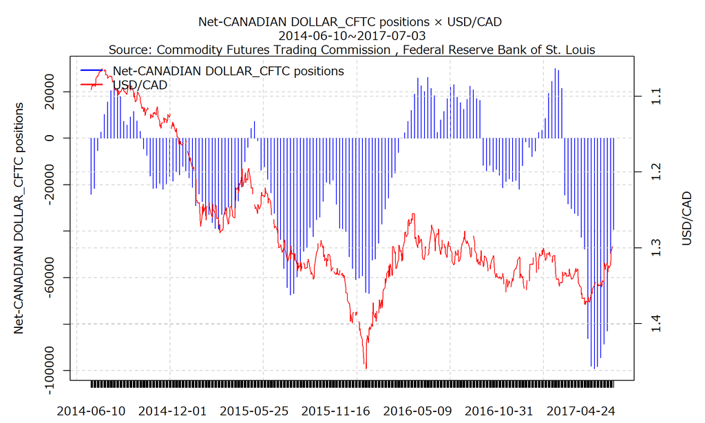

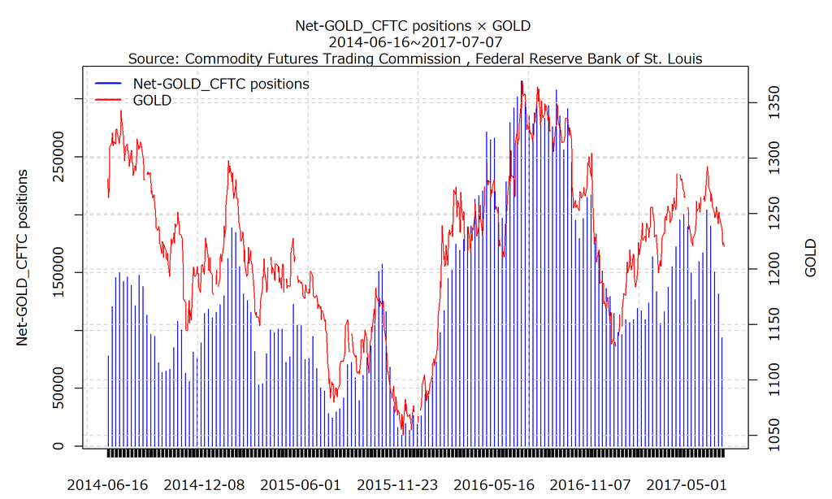

```
## 2014-01-07 ~ 2017-07-03
##         Long-JAPANESE YEN Short-JAPANESE YEN Net-JAPANESE YEN
## Min.              7828.00            22013.0       -128868.00
## 1st Qu.          26525.50            52752.5        -77858.00
## Median           41489.00            84198.0        -53787.00
## Mean             46545.36            82063.6        -35518.24
## 3rd Qu.          67747.00           106259.5          7501.50
## Max.            105710.00           158726.0         71870.00
##
##
## 2014-01-07 ~ 2017-07-03
##         Long-EURO FX Short-EURO FX Net-EURO FX
## Min.        38758.00       64828.0   -226560.0
## 1st Qu.     59862.00      143663.0   -142452.0
## Median      84383.00      182583.0    -85025.0
## Mean        90023.19      175386.8    -85363.6
## 3rd Qu.    110388.00      216256.0    -45332.0
## Max.       185925.00      271111.0     79053.0
##
##
## 2014-01-07 ~ 2017-07-03
##         Long-AUSTRALIAN DOLLAR Short-AUSTRALIAN DOLLAR Net-AUSTRALIAN DOLLAR
## Min.                   8627.00                21494.00            -76851.000
## 1st Qu.               40376.50                34576.50            -38147.500
## Median                51397.00                50546.00               124.000
## Mean                  50863.74                54740.26             -3876.519
## 3rd Qu.               65333.00                69811.00             27638.000
## Max.                 109932.00               111397.00             59540.000
##
##
## 2014-01-07 ~ 2017-07-03
##         Long-BRITISH POUND STERLING Short-BRITISH POUND STERLING Net-BRITISH POUND STERLING
## Min.                       27959.00                     36501.00                 -107844.00
## 1st Qu.                    37778.00                     52298.50                  -51628.50
## Median                     43509.00                     69397.00                  -30496.00
## Mean                       49052.78                     77410.96                  -28358.18
## 3rd Qu.                    54316.50                     94215.50                   -3228.00
## Max.                      100434.00                    154332.00                   56412.00
##
##
```

[output cut: 53 more lines]

```
## 1st Qu.             8917.00              5018.50          -1282.500
## Median             14733.00              7106.00           4149.000
## Mean               14743.77             11984.66           2759.114
## 3rd Qu.            19413.50             15627.50          12310.000
## Max.               30054.00             55915.00          26050.000
##
##
## 2014-01-07 ~ 2017-07-03
##         Long-GOLD Short-GOLD Net-GOLD
## Min.     139244.0   43644.00   9750.0
## 1st Qu.  173735.0   68305.50  75965.0
## Median   194299.0   83757.00 115820.0
## Mean     217878.4   88641.21 129237.2
## 3rd Qu.  243751.0  104397.50 167087.5
## Max.     389590.0  159441.00 315963.0
```

## 直近 15 週の時系列推移

## JAPANESE YEN - CHICAGO MERCANTILE EXCHANGE

| Date | Long-JAPANESE YEN | Short-JAPANESE YEN | Net-JAPANESE YEN | Unit |
| --- | --- | --- | --- | --- |
| 2017-03-28 | 42886 | 96067 | -53181 | (CONTRACTS OF JPY 12,500,000) |
| 2017-04-04 | 41313 | 87113 | -45800 | (CONTRACTS OF JPY 12,500,000) |
| 2017-04-11 | 43316 | 78080 | -34764 | (CONTRACTS OF JPY 12,500,000) |
| 2017-04-18 | 45761 | 76224 | -30463 | (CONTRACTS OF JPY 12,500,000) |
| 2017-04-25 | 48538 | 75407 | -26869 | (CONTRACTS OF JPY 12,500,000) |
| 2017-05-02 | 37519 | 68002 | -30483 | (CONTRACTS OF JPY 12,500,000) |
| 2017-05-09 | 42635 | 78942 | -36307 | (CONTRACTS OF JPY 12,500,000) |
| 2017-05-16 | 41963 | 101971 | -60008 | (CONTRACTS OF JPY 12,500,000) |
| 2017-05-23 | 41920 | 93576 | -51656 | (CONTRACTS OF JPY 12,500,000) |
| 2017-05-30 | 43404 | 95679 | -52275 | (CONTRACTS OF JPY 12,500,000) |

[output cut: 5 more lines]

## EURO FX - CHICAGO MERCANTILE EXCHANGE

| Date | Long-EURO FX | Short-EURO FX | Net-EURO FX | Unit |
| --- | --- | --- | --- | --- |
| 2017-03-28 | 163648 | 171571 | -7923 | (CONTRACTS OF EUR 125,000) |
| 2017-04-04 | 155468 | 166873 | -11405 | (CONTRACTS OF EUR 125,000) |
| 2017-04-11 | 173594 | 192550 | -18956 | (CONTRACTS OF EUR 125,000) |
| 2017-04-18 | 185786 | 207435 | -21649 | (CONTRACTS OF EUR 125,000) |
| 2017-04-25 | 157831 | 178726 | -20895 | (CONTRACTS OF EUR 125,000) |
| 2017-05-02 | 159418 | 161071 | -1653 | (CONTRACTS OF EUR 125,000) |
| 2017-05-09 | 155581 | 133182 | 22399 | (CONTRACTS OF EUR 125,000) |
| 2017-05-16 | 164234 | 126630 | 37604 | (CONTRACTS OF EUR 125,000) |
| 2017-05-23 | 175032 | 110187 | 64845 | (CONTRACTS OF EUR 125,000) |
| 2017-05-30 | 176226 | 103357 | 72869 | (CONTRACTS OF EUR 125,000) |

[output cut: 5 more lines]

## AUSTRALIAN DOLLAR - CHICAGO MERCANTILE EXCHANGE

| Date | Long-AUSTRALIAN DOLLAR | Short-AUSTRALIAN DOLLAR | Net-AUSTRALIAN DOLLAR | Unit |
| --- | --- | --- | --- | --- |
| 2017-03-28 | 90838 | 37700 | 53138 | (CONTRACTS OF AUD 100,000) |
| 2017-04-04 | 90215 | 40622 | 49593 | (CONTRACTS OF AUD 100,000) |
| 2017-04-11 | 76747 | 31596 | 45151 | (CONTRACTS OF AUD 100,000) |
| 2017-04-18 | 70392 | 27130 | 43262 | (CONTRACTS OF AUD 100,000) |
| 2017-04-25 | 64684 | 21982 | 42702 | (CONTRACTS OF AUD 100,000) |
| 2017-05-02 | 64169 | 21494 | 42675 | (CONTRACTS OF AUD 100,000) |
| 2017-05-09 | 56471 | 30687 | 25784 | (CONTRACTS OF AUD 100,000) |
| 2017-05-16 | 52244 | 45900 | 6344 | (CONTRACTS OF AUD 100,000) |
| 2017-05-23 | 42892 | 40257 | 2635 | (CONTRACTS OF AUD 100,000) |
| 2017-05-30 | 43148 | 40081 | 3067 | (CONTRACTS OF AUD 100,000) |

[output cut: 5 more lines]

## BRITISH POUND STERLING - CHICAGO MERCANTILE EXCHANGE

| Date | Long-BRITISH POUND STERLING | Short-BRITISH POUND STERLING | Net-BRITISH POUND STERLING | Unit |
| --- | --- | --- | --- | --- |
| 2017-03-28 | 35055 | 139130 | -104075 | (CONTRACTS OF GBP 62,500) |
| 2017-04-04 | 30741 | 130414 | -99673 | (CONTRACTS OF GBP 62,500) |
| 2017-04-11 | 31871 | 137772 | -105901 | (CONTRACTS OF GBP 62,500) |
| 2017-04-18 | 48348 | 147838 | -99490 | (CONTRACTS OF GBP 62,500) |
| 2017-04-25 | 54050 | 145232 | -91182 | (CONTRACTS OF GBP 62,500) |
| 2017-05-02 | 54281 | 135645 | -81364 | (CONTRACTS OF GBP 62,500) |
| 2017-05-09 | 44910 | 91708 | -46798 | (CONTRACTS OF GBP 62,500) |
| 2017-05-16 | 48369 | 81364 | -32995 | (CONTRACTS OF GBP 62,500) |
| 2017-05-23 | 49166 | 73033 | -23867 | (CONTRACTS OF GBP 62,500) |
| 2017-05-30 | 45574 | 75225 | -29651 | (CONTRACTS OF GBP 62,500) |

[output cut: 5 more lines]

## SWISS FRANC - CHICAGO MERCANTILE EXCHANGE

| Date | Long-SWISS FRANC | Short-SWISS FRANC | Net-SWISS FRANC | Unit |
| --- | --- | --- | --- | --- |
| 2017-03-28 | 6886 | 23278 | -16392 | (CONTRACTS OF CHF 125,000) |
| 2017-04-04 | 5694 | 19519 | -13825 | (CONTRACTS OF CHF 125,000) |
| 2017-04-11 | 13107 | 23235 | -10128 | (CONTRACTS OF CHF 125,000) |
| 2017-04-18 | 10830 | 24632 | -13802 | (CONTRACTS OF CHF 125,000) |
| 2017-04-25 | 7654 | 24971 | -17317 | (CONTRACTS OF CHF 125,000) |
| 2017-05-02 | 4448 | 22156 | -17708 | (CONTRACTS OF CHF 125,000) |
| 2017-05-09 | 8480 | 23676 | -15196 | (CONTRACTS OF CHF 125,000) |
| 2017-05-16 | 3946 | 25108 | -21162 | (CONTRACTS OF CHF 125,000) |
| 2017-05-23 | 6118 | 25903 | -19785 | (CONTRACTS OF CHF 125,000) |
| 2017-05-30 | 8735 | 27247 | -18512 | (CONTRACTS OF CHF 125,000) |

[output cut: 5 more lines]

## NEW ZEALAND DOLLAR - CHICAGO MERCANTILE EXCHANGE

| Date | Long-NEW ZEALAND DOLLAR | Short-NEW ZEALAND DOLLAR | Net-NEW ZEALAND DOLLAR | Unit |
| --- | --- | --- | --- | --- |
| 2017-03-28 | 16216 | 28845 | -12629 | (CONTRACTS OF NZD 100,000) |
| 2017-04-04 | 17009 | 31733 | -14724 | (CONTRACTS OF NZD 100,000) |
| 2017-04-11 | 19008 | 34161 | -15153 | (CONTRACTS OF NZD 100,000) |
| 2017-04-18 | 18320 | 33326 | -15006 | (CONTRACTS OF NZD 100,000) |
| 2017-04-25 | 18693 | 34097 | -15404 | (CONTRACTS OF NZD 100,000) |
| 2017-05-02 | 19190 | 31160 | -11970 | (CONTRACTS OF NZD 100,000) |
| 2017-05-09 | 12070 | 22856 | -10786 | (CONTRACTS OF NZD 100,000) |
| 2017-05-16 | 11918 | 23872 | -11954 | (CONTRACTS OF NZD 100,000) |
| 2017-05-23 | 14018 | 23235 | -9217 | (CONTRACTS OF NZD 100,000) |
| 2017-05-30 | 16886 | 22425 | -5539 | (CONTRACTS OF NZD 100,000) |

[output cut: 5 more lines]

## CANADIAN DOLLAR - CHICAGO MERCANTILE EXCHANGE

| Date | Long-CANADIAN DOLLAR | Short-CANADIAN DOLLAR | Net-CANADIAN DOLLAR | Unit |
| --- | --- | --- | --- | --- |
| 2017-03-28 | 30419 | 58636 | -28217 | (CONTRACTS OF CAD 100,000) |
| 2017-04-04 | 38535 | 68760 | -30225 | (CONTRACTS OF CAD 100,000) |
| 2017-04-11 | 31432 | 63766 | -32334 | (CONTRACTS OF CAD 100,000) |
| 2017-04-18 | 37306 | 70558 | -33252 | (CONTRACTS OF CAD 100,000) |
| 2017-04-25 | 52545 | 95187 | -42642 | (CONTRACTS OF CAD 100,000) |
| 2017-05-02 | 66565 | 114269 | -47704 | (CONTRACTS OF CAD 100,000) |
| 2017-05-09 | 47412 | 133627 | -86215 | (CONTRACTS OF CAD 100,000) |
| 2017-05-16 | 39130 | 137130 | -98000 | (CONTRACTS OF CAD 100,000) |
| 2017-05-23 | 29681 | 128790 | -99109 | (CONTRACTS OF CAD 100,000) |
| 2017-05-30 | 23711 | 121898 | -98187 | (CONTRACTS OF CAD 100,000) |

[output cut: 5 more lines]

## RUSSIAN RUBLE - CHICAGO MERCANTILE EXCHANGE

| Date | Long-RUSSIAN RUBLE | Short-RUSSIAN RUBLE | Net-RUSSIAN RUBLE | Unit |
| --- | --- | --- | --- | --- |
| 2017-03-28 | 20805 | 1429 | 19376 | (CONTRACTS OF RUB 2,500,000) |
| 2017-04-04 | 26561 | 6429 | 20132 | (CONTRACTS OF RUB 2,500,000) |
| 2017-04-11 | 27233 | 7170 | 20063 | (CONTRACTS OF RUB 2,500,000) |
| 2017-04-18 | 27013 | 7353 | 19660 | (CONTRACTS OF RUB 2,500,000) |
| 2017-04-25 | 27896 | 7687 | 20209 | (CONTRACTS OF RUB 2,500,000) |
| 2017-05-02 | 22631 | 3665 | 18966 | (CONTRACTS OF RUB 2,500,000) |
| 2017-05-09 | 12648 | 1653 | 10995 | (CONTRACTS OF RUB 2,500,000) |
| 2017-05-16 | 11976 | 1983 | 9993 | (CONTRACTS OF RUB 2,500,000) |
| 2017-05-23 | 10272 | 2147 | 8125 | (CONTRACTS OF RUB 2,500,000) |
| 2017-05-30 | 9990 | 2127 | 7863 | (CONTRACTS OF RUB 2,500,000) |

[output cut: 5 more lines]

## MEXICAN PESO - CHICAGO MERCANTILE EXCHANGE

| Date | Long-MEXICAN PESO | Short-MEXICAN PESO | Net-MEXICAN PESO | Unit |
| --- | --- | --- | --- | --- |
| 2017-03-28 | 72728 | 77465 | -4737 | (CONTRACTS OF MXN 500,000) |
| 2017-04-04 | 80979 | 90667 | -9688 | (CONTRACTS OF MXN 500,000) |
| 2017-04-11 | 86813 | 99488 | -12675 | (CONTRACTS OF MXN 500,000) |
| 2017-04-18 | 97027 | 82783 | 14244 | (CONTRACTS OF MXN 500,000) |
| 2017-04-25 | 91689 | 75651 | 16038 | (CONTRACTS OF MXN 500,000) |
| 2017-05-02 | 91142 | 76027 | 15115 | (CONTRACTS OF MXN 500,000) |
| 2017-05-09 | 92514 | 22611 | 69903 | (CONTRACTS OF MXN 500,000) |
| 2017-05-16 | 92686 | 22632 | 70054 | (CONTRACTS OF MXN 500,000) |
| 2017-05-23 | 98609 | 44311 | 54298 | (CONTRACTS OF MXN 500,000) |
| 2017-05-30 | 112479 | 37477 | 75002 | (CONTRACTS OF MXN 500,000) |

[output cut: 5 more lines]

## BRAZILIAN REAL - CHICAGO MERCANTILE EXCHANGE

| Date | Long-BRAZILIAN REAL | Short-BRAZILIAN REAL | Net-BRAZILIAN REAL | Unit |
| --- | --- | --- | --- | --- |
| 2017-03-28 | 18832 | 2367 | 16465 | (CONTRACTS OF BRL 100,000) |
| 2017-04-04 | 18918 | 3484 | 15434 | (CONTRACTS OF BRL 100,000) |
| 2017-04-11 | 17923 | 3664 | 14259 | (CONTRACTS OF BRL 100,000) |
| 2017-04-18 | 17149 | 3857 | 13292 | (CONTRACTS OF BRL 100,000) |
| 2017-04-25 | 16651 | 4421 | 12230 | (CONTRACTS OF BRL 100,000) |
| 2017-05-02 | 11987 | 4504 | 7483 | (CONTRACTS OF BRL 100,000) |
| 2017-05-09 | 10996 | 5021 | 5975 | (CONTRACTS OF BRL 100,000) |
| 2017-05-16 | 11542 | 3970 | 7572 | (CONTRACTS OF BRL 100,000) |
| 2017-05-23 | 11909 | 4259 | 7650 | (CONTRACTS OF BRL 100,000) |
| 2017-05-30 | 12516 | 4409 | 8107 | (CONTRACTS OF BRL 100,000) |

[output cut: 5 more lines]

## GOLD - COMMODITY EXCHANGE INC.

| Date | Long-GOLD | Short-GOLD | Net-GOLD | Unit |
| --- | --- | --- | --- | --- |
| 2017-03-28 | 227839 | 90019 | 137820 | (CONTRACTS OF 100 TROY OUNCES) |
| 2017-04-04 | 239061 | 83625 | 155436 | (CONTRACTS OF 100 TROY OUNCES) |
| 2017-04-11 | 253004 | 80338 | 172666 | (CONTRACTS OF 100 TROY OUNCES) |
| 2017-04-18 | 279311 | 83543 | 195768 | (CONTRACTS OF 100 TROY OUNCES) |
| 2017-04-25 | 287468 | 86791 | 200677 | (CONTRACTS OF 100 TROY OUNCES) |
| 2017-05-02 | 276032 | 86398 | 189634 | (CONTRACTS OF 100 TROY OUNCES) |
| 2017-05-09 | 236115 | 86109 | 150006 | (CONTRACTS OF 100 TROY OUNCES) |
| 2017-05-16 | 221532 | 94808 | 126724 | (CONTRACTS OF 100 TROY OUNCES) |
| 2017-05-23 | 241752 | 81985 | 159767 | (CONTRACTS OF 100 TROY OUNCES) |
| 2017-05-30 | 250542 | 83452 | 167090 | (CONTRACTS OF 100 TROY OUNCES) |

[output cut: 5 more lines]

## 直近 5 週のネットポジション

| Item | 2017-06-06 | 2017-06-13 | 2017-06-20 | 2017-06-27 | 2017-07-03 |
| --- | --- | --- | --- | --- | --- |
| Net-JAPANESE YEN | -55,027 | -50,553 | -49,959 | -61,350 | -75,036 |
| Net-EURO FX | 74,009 | 79,053 | 44,852 | 58,695 | 77,464 |
| Net-AUSTRALIAN DOLLAR | -114 | -1,511 | 15,033 | 19,749 | 32,414 |
| Net-BRITISH POUND STERLING | -36,716 | -39,441 | -37,604 | -39,133 | -27,767 |
| Net-SWISS FRANC | -16,555 | -14,460 | -2,982 | -4,669 | -113 |
| Net-NEW ZEALAND DOLLAR | -1,785 | 1,595 | 21,455 | 25,233 | 29,133 |
| Net-CANADIAN DOLLAR | -94,501 | -88,595 | -82,881 | -49,495 | -39,372 |
| Net-RUSSIAN RUBLE | 7,622 | 6,353 | 1,432 | -668 | -3,794 |
| Net-MEXICAN PESO | 84,821 | 95,814 | 48,985 | 81,007 | 84,859 |
| Net-BRAZILIAN REAL | 4,149 | 3,906 | 3,970 | 4,282 | 4,024 |
| Net-GOLD | 204,465 | 190,274 | 150,675 | 131,672 | 93,799 |

## ネットポジションがロングからショート又はその逆へと変化した週:±0コントラクトはネットロングとする。

#### Net-JAPANESE YEN

| Date | Net-JAPANESE YEN |
| --- | --- |
| 2016-01-05 | 4,103 |
| 2016-11-29 | -269 |

#### 2016-11-29から2017-07-03まで32週連続でネットショート

#### Net-EURO FX

| Date | Net-EURO FX |
| --- | --- |
| 2014-01-21 | -3,772 |
| 2014-01-28 | 14,347 |
| 2014-02-04 | -13,610 |
| 2014-02-18 | 8,599 |
| 2014-05-13 | -2,175 |
| 2017-05-09 | 22,399 |

#### 2017-05-09から2017-07-03まで9週連続でネットロング

#### Net-AUSTRALIAN DOLLAR

| Date | Net-AUSTRALIAN DOLLAR |
| --- | --- |
| 2014-04-08 | 3,310 |
| 2014-09-30 | -2,017 |
| 2015-05-05 | 626 |
| 2015-06-02 | -13,256 |
| 2016-02-16 | 2,807 |
| 2016-05-31 | -4,758 |
| 2016-07-05 | 4,903 |
| 2016-12-27 | -1,510 |
| 2017-01-17 | 4,845 |
| 2017-06-06 | -114 |
| 2017-06-20 | 15,033 |

#### 2017-06-20から2017-07-03まで3週連続でネットロング

#### Net-BRITISH POUND STERLING

| Date | Net-BRITISH POUND STERLING |
| --- | --- |
| 2014-09-16 | -6,581 |
| 2014-09-30 | 3,589 |
| 2014-10-07 | -1,075 |
| 2015-08-25 | 3,299 |
| 2015-09-01 | -11,239 |
| 2015-09-22 | 1,267 |
| 2015-09-29 | -2,047 |
| 2015-10-20 | 7,537 |
| 2015-11-10 | -15,770 |

#### 2015-11-10から2017-07-03まで87週連続でネットショート

#### Net-SWISS FRANC

| Date | Net-SWISS FRANC |
| --- | --- |
| 2014-01-14 | -2,941 |
| 2014-02-04 | 2,220 |
| 2014-02-18 | -2,828 |
| 2014-02-25 | 358 |
| 2014-05-27 | -3,872 |
| 2014-06-17 | 3,520 |
| 2014-06-24 | -5,372 |
| 2015-03-17 | 2,235 |
| 2015-03-24 | -3,955 |
| 2015-03-31 | 706 |
| 2015-08-04 | -1,466 |
| 2015-09-15 | 3,782 |
| 2015-09-22 | -1,876 |
| 2015-10-20 | 625 |
| 2015-11-03 | -7,035 |
| 2015-12-15 | 1,951 |
| 2016-01-26 | -4,503 |
| 2016-03-15 | 5,262 |
| 2016-06-07 | -9,645 |
| 2016-06-14 | 7,130 |
| 2016-08-02 | -1,715 |
| 2016-08-09 | 107 |
| 2016-08-16 | -1,545 |
| 2016-08-23 | 1,885 |
| 2016-09-27 | -5,956 |
| 2016-12-20 | 7,110 |
| 2016-12-27 | -10,091 |

#### 2016-12-27から2017-07-03まで28週連続でネットショート

#### Net-NEW ZEALAND DOLLAR

| Date | Net-NEW ZEALAND DOLLAR |
| --- | --- |
| 2014-10-07 | -100 |
| 2015-03-31 | 4,031 |
| 2015-05-19 | -2,231 |
| 2015-10-13 | 692 |
| 2015-12-22 | -221 |
| 2016-01-05 | 1,579 |
| 2016-01-19 | -2,954 |
| 2016-03-15 | 1,290 |
| 2016-06-14 | -3,818 |
| 2016-07-12 | 1,011 |
| 2016-08-09 | -613 |
| 2016-08-30 | 1,893 |
| 2016-09-20 | -7,916 |
| 2016-11-08 | 2,505 |
| 2016-11-22 | -533 |
| 2017-02-07 | 1,845 |
| 2017-03-07 | -4,425 |
| 2017-06-13 | 1,595 |

#### 2017-06-13から2017-07-03まで4週連続でネットロング

#### Net-CANADIAN DOLLAR

| Date | Net-CANADIAN DOLLAR |
| --- | --- |
| 2014-07-01 | 2,695 |
| 2014-09-30 | -4,566 |
| 2015-05-19 | 4,348 |
| 2015-06-02 | -1,025 |
| 2016-04-05 | 97 |
| 2016-09-27 | -11,615 |
| 2017-01-24 | 2,519 |
| 2017-03-21 | -24,403 |

#### 2017-03-21から2017-07-03まで16週連続でネットショート

#### Net-RUSSIAN RUBLE

| Date | Net-RUSSIAN RUBLE |
| --- | --- |
| 2014-01-21 | -286 |
| 2014-06-03 | 124 |
| 2014-06-10 | -129 |
| 2014-06-17 | 3,826 |
| 2014-08-05 | -2,507 |
| 2014-12-16 | 2,587 |
| 2015-07-14 | -2,001 |
| 2015-10-13 | 1,171 |
| 2015-12-22 | -835 |
| 2016-01-19 | 651 |
| 2017-06-27 | -668 |

#### 2017-06-27から2017-07-03まで2週連続でネットショート

#### Net-MEXICAN PESO

| Date | Net-MEXICAN PESO |
| --- | --- |
| 2014-01-21 | -3,628 |
| 2014-04-01 | 21,784 |
| 2014-08-12 | -41 |
| 2014-08-19 | 12,407 |
| 2014-09-30 | -7,314 |
| 2015-04-14 | 8,361 |
| 2015-04-21 | -13,675 |
| 2017-04-18 | 14,244 |

#### 2017-04-18から2017-07-03まで12週連続でネットロング

#### Net-BRAZILIAN REAL

| Date | Net-BRAZILIAN REAL |
| --- | --- |
| 2014-08-26 | -6,753 |
| 2015-01-27 | 3,768 |
| 2015-03-03 | -8,598 |
| 2015-05-12 | 5,814 |
| 2015-06-02 | -1,251 |
| 2015-06-30 | 3,544 |
| 2015-08-04 | -4,464 |
| 2015-10-13 | 89 |
| 2015-10-20 | -58 |
| 2015-11-03 | 1,700 |
| 2016-01-05 | -2,070 |
| 2016-02-23 | 1,195 |
| 2016-05-03 | -845 |
| 2016-05-10 | 192 |
| 2016-05-31 | -282 |
| 2016-06-07 | 12,848 |
| 2016-08-02 | -97 |
| 2016-08-16 | 366 |

#### 2016-08-16から2017-07-03まで47週連続でネットロング